# IODS course project

Suvi

# About the project

- Introduction to open data science will surely help me with my work and studies. I’m looking forward of learning new things with R! My github repository: https://github.com/suviki/IODS-project *

# Chapter 2 - working with data / regression analysis

*I learned to do new things with R!*

- I learned what graphical things it is possible to do with R, I haven’t tried this before.
- I also learned how to do regression analysis in R. Also a new thing for me!

# Suvi Kivi 11.11.2018. This file shows what I have learned this week!

# DATA WRANGLING

## 2. Taking dataset in & dimension and structure of the data

*Taking dataset in*

lrn2014 <- read.table(“http://www.helsinki.fi/~kvehkala/JYTmooc/JYTOPKYS3-data.txt”, sep=“”, header=TRUE)

*Dimension of the data*

dim (lrn2014)

- there is 183 obs and 60 variables in the dataset

*Structure of the data*

str(lrn2014)

- there are 59 integer variables and only one factor variable (gender)

## 3. Analysis dataset

*Access the dplyr library*

install.packages(“dplyr”)

library(dplyr)

*Questions related to deep, surface and strategic learning*

deep_questions <- c(“D03”, “D11”, “D19”, “D27”, “D07”, “D14”, “D22”, “D30”,“D06”, “D15”, “D23”, “D31”)

surface_questions <- c(“SU02”,“SU10”,“SU18”,“SU26”, “SU05”,“SU13”,“SU21”,“SU29”,“SU08”,“SU16”,“SU24”,“SU32”)

strategic_questions <- c(“ST01”,“ST09”,“ST17”,“ST25”,“ST04”,“ST12”,“ST20”,“ST28”)

*Selecting columns related to deep learning and creating a new column ‘deep’ by averaging*

deep_columns <- select(lrn2014, one_of(deep_questions))

lrn2014$deep <- rowMeans(deep_columns)

*Selecting columns related to surface learning and creating column ‘surf’ by averaging*

surface_columns <- select(lrn2014, one_of(surface_questions))

lrn2014$surf <- rowMeans(surface_columns)

*Selecting columns related to strategic learning and creating column ‘stra’ by averaging*

strategic_columns <- select(lrn2014, one_of(strategic_questions))

lrn2014$stra <- rowMeans(strategic_columns)

*Choosing the right columns to keep*

keep_columns <- c(“gender”,“Age”,“Attitude”, “deep”, “stra”, “surf”, “Points”)

*Selecting the ‘keep_columns’ to create a new dataset*

learning2014 <- select(lrn2014, one_of(keep_columns))

*Select rows where points is greater than zero*

learning2014 <- filter(learning2014, Points > 0)

- now there are 166 obs. and 7 variables in the dataset

## 4. Setting the working directory and writing/reading csv-files

*Setting the working directory*

setwd(“/Users/suvi/Documents/GitHub/IODS-project”)

*Write csv*

?write.csv

write.csv(learning2014, “/Users/suvi/Documents/GitHub/IODS-project/Data/learning2014.csv”)

*Read csv*

?read.csv

read.csv(“/Users/suvi/Documents/GitHub/IODS-project/Data/learning2014.csv”)

*Structure of the csv*

str(“/Users/suvi/Documents/GitHub/IODS-project/Data/learning2014.csv”)

head(“/Users/suvi/Documents/GitHub/IODS-project/Data/learning2014.csv”)

# ANALYSIS

## 1. Looking at learning 2014 dataset

Data is already in after data wrangling and that is why I don’t read it from the web.

dim(learning2014)

str (learning2014)

- Learning2014 dataset shows information about student, their attitudes and how they perform in tests.
- There are information about 166 students in the data and the variables are gender, age, attitude, deep, stra, surf and points.
- Gender and age are basic information about the student. Attitude shows students’ attitude towards statistics (many questions in the backround).
- Variables deep, stra and surf are collected together from different questions and the data shows the average of the Likert-scale (1-5).
- Variable points shows the students’ exam points.

## 2. graphical overview of the data

*Graphical overwiev helps to understand the data. If we want to see the summaries of the variables, histogram is one way to see that.*

hist_age <- hist(learning2014$Age)

hist_attitude <- hist(learning2014$Attitude)

*Plots are also a good way to explore the data. For example we can see the points and the attitude in the same plot*

install.packages(“ggplot2”)

library(ggplot2)

plot1 <- ggplot(learning2014, aes(x = Attitude, y = Points))

plot2 <- plot1 + geom_point()

plot2

plot3 <- plot2 + geom_smooth(method = “lm”)

plot3

*Also a good way to see data by all the variables, is to use pairs (pairs or for example ggpairs)*

pairs(learning2014[-1])

install.packages(“GGally”)

library(GGally)

p <- ggpairs(learning2014, mapping = aes(), lower = list(combo = wrap(“facethist”, bins = 20)))

p

## 3. Choosing three explanatory variables -> regression analysis between attitude and points

*Simple regression analysis: attitude and points*

keep_columns <- c(“Age”, “Attitude”, “deep”, “Points”)

variables <- select(learning2014, one_of(keep_columns))

qplot(Attitude, Points, data = variables) + geom_smooth(method = “lm”)

linear_model <- lm(Points ~ Attitude, data = variables)

## 4. Summary of the models (simple and multiple models)

*Summary (linear_model)*

*Multiple regression analysis*

linear_model2 <- lm(Points ~ Attitude + Age + deep, data = variables)

summary(linear_model2)

## 5. Plots

plot(linear_model)

plot(linar_model2)

# Chapter 3 - Data wrangling and logistic regression

## Suvi Kivi 13.11.2018. This file shows what I have learned this week.

# ANALYSIS

## 2. Here is the data

```r
alc2 <- read.table("http://s3.amazonaws.com/assets.datacamp.com/production/course_2218/datasets/alc.txt", sep=",", header=TRUE)
```

```
## 'data.frame':    382 obs. of  35 variables:
##  $ school    : Factor w/ 2 levels "GP","MS": 1 1 1 1 1 1 1 1 1 1 ...
##  $ sex       : Factor w/ 2 levels "F","M": 1 1 1 1 1 2 2 1 2 2 ...
##  $ age       : int  18 17 15 15 16 16 16 17 15 15 ...
##  $ address   : Factor w/ 2 levels "R","U": 2 2 2 2 2 2 2 2 2 2 ...
##  $ famsize   : Factor w/ 2 levels "GT3","LE3": 1 1 2 1 1 2 2 1 2 1 ...
##  $ Pstatus   : Factor w/ 2 levels "A","T": 1 2 2 2 2 2 2 1 1 2 ...
##  $ Medu      : int  4 1 1 4 3 4 2 4 3 3 ...
##  $ Fedu      : int  4 1 1 2 3 3 2 4 2 4 ...
##  $ Mjob      : Factor w/ 5 levels "at_home","health",..: 1 1 1 2 3 4 3 3 4 3 ...
##  $ Fjob      : Factor w/ 5 levels "at_home","health",..: 5 3 3 4 3 3 3 5 3 3 ...
##  $ reason    : Factor w/ 4 levels "course","home",..: 1 1 3 2 2 4 2 2 2 2 ...
##  $ nursery   : Factor w/ 2 levels "no","yes": 2 1 2 2 2 2 2 2 2 2 ...
##  $ internet  : Factor w/ 2 levels "no","yes": 1 2 2 2 1 2 2 1 2 2 ...
##  $ guardian  : Factor w/ 3 levels "father","mother",..: 2 1 2 2 1 2 2 2 2 2 ...
```

[output cut: 21 more lines]

- There are 382 obs and 35 variables in the dataset. Data describes students achievement in secondary education of two Portuguese schools.
- Data includes students grades and demographic, social and school related features.
- Data was collected by using school reports and questionnaires.

## 3. How I assume that variables relates with alchol consumption?

From the data I chose sex, age, Pstatus (parent’s cohabitation status) and famsup (family educational support). Here is my own hypothesis of their relationship with alcohol consumption.

- I assume that there is not so much correlation between sex and alcohol consumption
- I assume that age correlates a bit with alcohol consumption.

```
##    Min. 1st Qu.  Median    Mean 3rd Qu.    Max.
##   15.00   16.00   17.00   16.59   17.00   22.00
```

The students age is between 15 and 22 and I guess that the age will slowly raise the alcohol consumption.

- I assume that Pstatus correlates little with alcohol consumption. Students are young and their parents cohabitation status may have an impact to their behavior.
- I believe that the biggest correlation with alcohol consumtion is with famsup. My own hypothesis is that if there family supports student then the alcohol consumption is lesser.

## 4. How the 4 chosen variables really relates with alcohol consumption?

Here is numerically and graphically pointed how sex, age, Psatus and famsup corralates with alcohol consumption.

```r
library(dplyr)
keep_columns <- c("sex","age","Pstatus", "famsup", "alc_use")
alc3 <- select (alc2, one_of(keep_columns))
```

### Sex

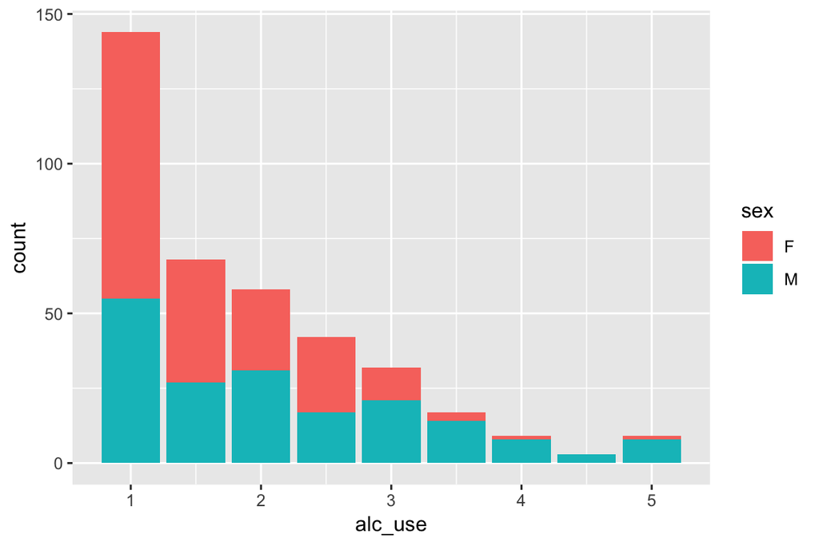

```r
library(gmodels)
library(ggplot2)
sex <- CrossTable(alc3$sex, alc3$alc_use)
```

Looks like there is more alcohol use in men than in female. In female there is more often answers 1-2,5 and in male it more diffused. Looks like my hypothesis went wrong.

### Age

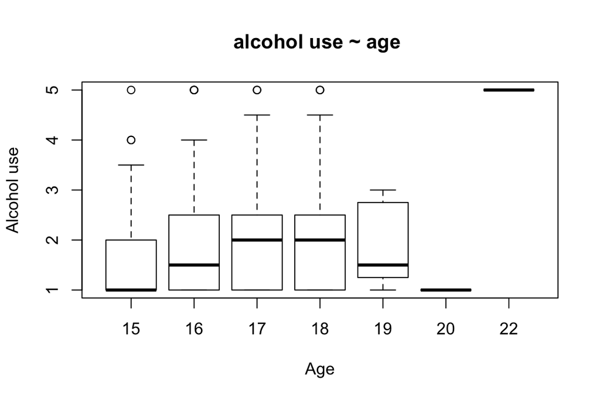

Box plots visualizes the 25th, 50th and 75th percentiles (the box), the typical range (the whiskers) and the outliers of a variable. At the age of 17-18 alcohol use is more common than in other age groups.

### parents cohabitation status (Psatus)

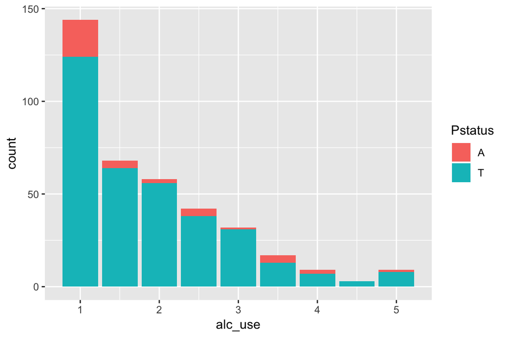

```r
Pstatus <- CrossTable(alc3$Pstatus, alc3$alc_use)
Pstatus
```

There is not so much difference between those student whose parents are divorced to those whose parents are still together. The number of students whose parents are divorced is much less than students whose parents are together. My hypothesis went wrong.

### family support (famsup)

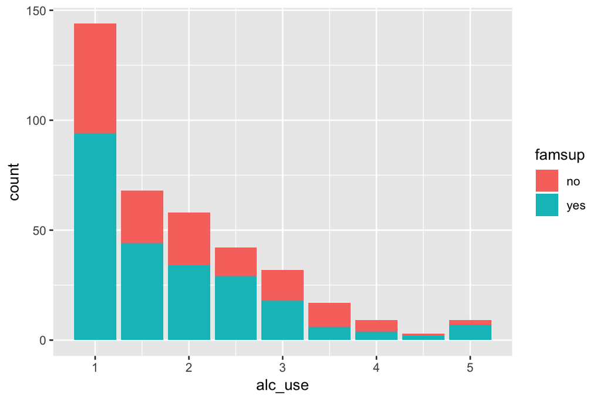

```r
famsup <- CrossTable(alc3$famsup, alc3$alc_use)
famsup
```

## 5. Logistic regression

```
##
## Call:  glm(formula = high_use ~ sex + age + Pstatus + famsup - 1, family = "binomial",
##     data = alc2)
##
## Coefficients:
##      sexF       sexM        age   PstatusT  famsupyes
## -4.650529  -3.752118   0.209168  -0.204081   0.001453
##
## Degrees of Freedom: 382 Total (i.e. Null);  377 Residual
## Null Deviance:       529.6
## Residual Deviance: 442.6     AIC: 452.6
```

```
##         sexF         sexM          age     PstatusT    famsupyes
## -4.650529045 -3.752117717  0.209167575 -0.204081256  0.001453275
```

```
##
## Call:
## glm(formula = high_use ~ sex + age + Pstatus + famsup - 1, family = "binomial",
##     data = alc2)
##
## Deviance Residuals:
##     Min       1Q   Median       3Q      Max
## -1.3652  -0.8553  -0.6947   1.2596   1.9402
##
## Coefficients:
##            Estimate Std. Error z value Pr(>|z|)
## sexF      -4.650529   1.705347  -2.727  0.00639 **
## sexM      -3.752118   1.684643  -2.227  0.02593 *
## age        0.209168   0.098717   2.119  0.03410 *
## PstatusT  -0.204081   0.380699  -0.536  0.59191
## famsupyes  0.001453   0.240731   0.006  0.99518
## ---
## Signif. codes:  0 '***' 0.001 '**' 0.01 '*' 0.05 '.' 0.1 ' ' 1
##
## (Dispersion parameter for binomial family taken to be 1)
##
##     Null deviance: 529.56  on 382  degrees of freedom
## Residual deviance: 442.58  on 377  degrees of freedom
## AIC: 452.58
##
## Number of Fisher Scoring iterations: 4
```

```
## Analysis of Deviance Table
##
## Model: binomial, link: logit
##
## Response: high_use
##
## Terms added sequentially (first to last)
##
##
##         Df Deviance Resid. Df Resid. Dev Pr(>Chi)
## NULL                      382     529.56
## sex      2   82.179       380     447.39  < 2e-16 ***
## age      1    4.526       379     442.86  0.03338 *
## Pstatus  1    0.282       378     442.58  0.59522
## famsup   1    0.000       377     442.58  0.99518
## ---
## Signif. codes:  0 '***' 0.001 '**' 0.01 '*' 0.05 '.' 0.1 ' ' 1
```